[output not shown]

### Machine Learning and Housing Predictions

Using linear regression modeling, we aim to predict the individual housing prices of a hold out sample dataset *(holdOut == 1)*

### Data

Using publicly available, almost exclusively from [San Francisco Open Data](https://datasf.org/opendata/) we compiled a series of variables that we suspected would be indicative of housing markets and the prices of homes. We looked for different types of variables to suggest different trends, while also considering a variety of data structures and spatial patterns.

#### Summary Statistics Table

Below is a table of summary statistics comprising each of the variables included in our prediction model.

[output not shown]

#### Correlation Matrix

Below is a correlation matrix comprising each of the variables included in our prediction model.

[figure not shown]

### Home Price Correlation Scatterplots

Below are four scatterplots of variables we found interesting.

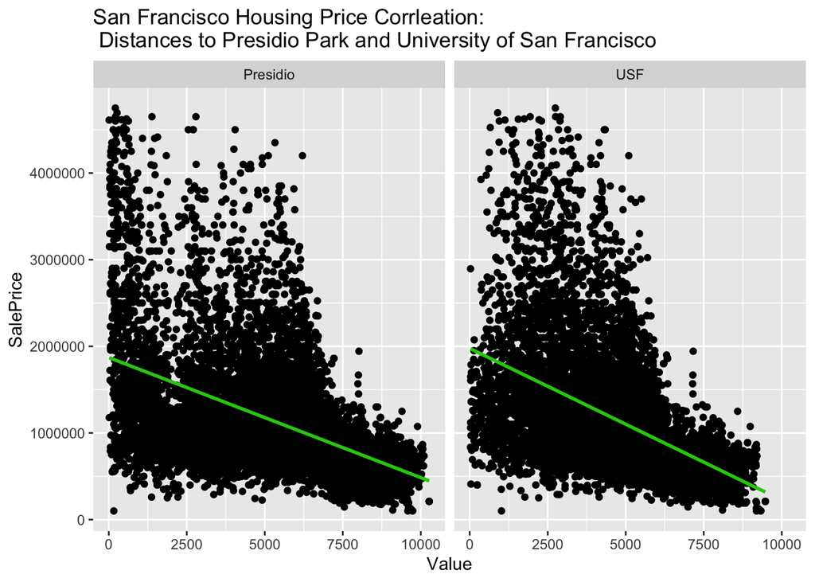

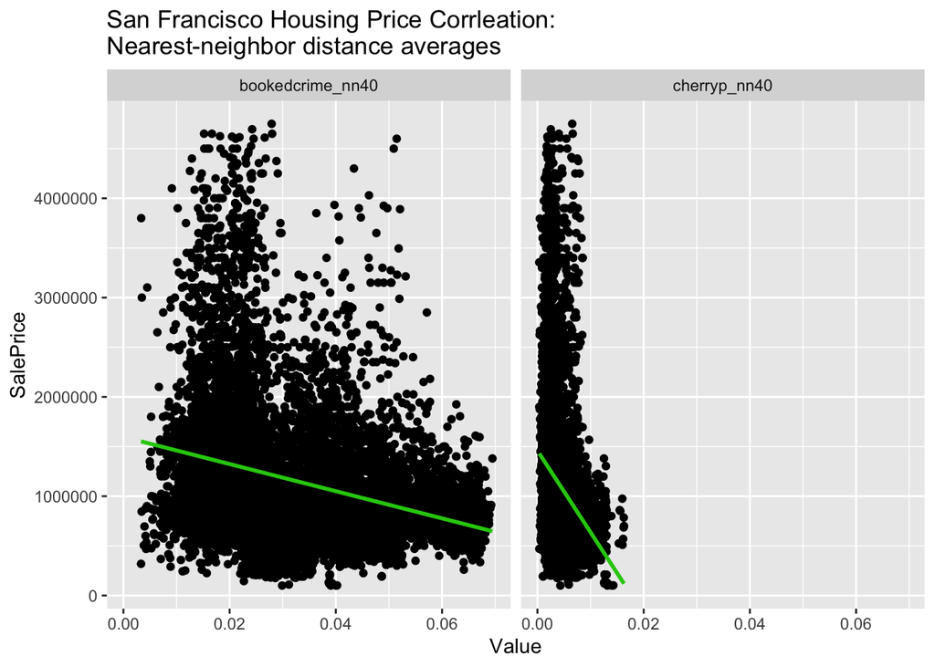

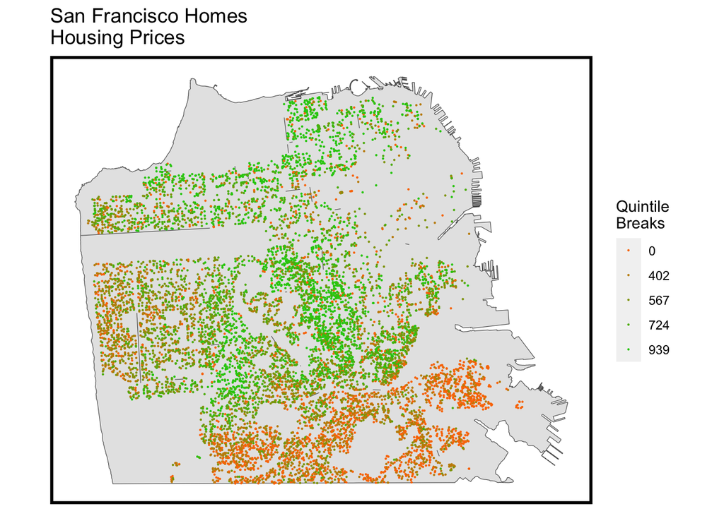

### Maps of 3 Independent Variables

[figure not shown]

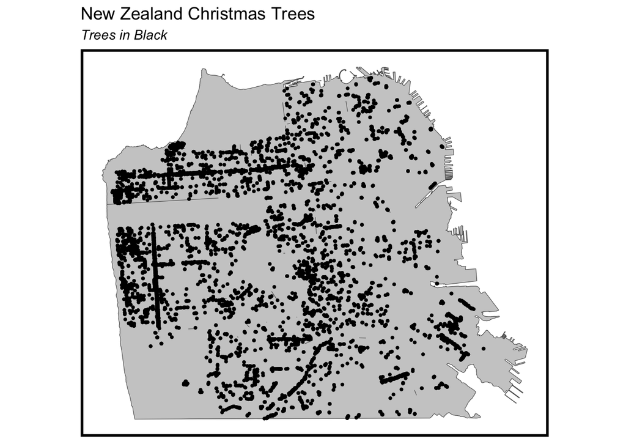

[figure not shown]

## Methods

Program Setup Our machine learning program was set up in R. First a variety of libraries were installed and loaded which are used to run the various functions within our program.

```r
#change sci notation
options(scipen=999)

#load libraries
library(tidyverse)
library(sf)
library(spdep)
library(caret)
library(ckanr)
library(FNN)
library(grid)
library(gridExtra)
library(corrplot)
library(viridis)
library(stargazer)
library(tigris)
library(ggmap)
library(sp)
library(dplyr)
library(stringr)
library(lwgeom)
library(tidycensus)
```

Map and plot themes were defined for use in visual presentations.

```r
# define map and plotting themes
mapTheme <- function(base_size = 12) {
  theme(
    text = element_text( color = "black"),
    plot.title = element_text(size = 14,colour = "black"),
    plot.subtitle=element_text(face="italic"),
    plot.caption=element_text(hjust=0),
    axis.ticks = element_blank(),
    panel.background = element_blank(),axis.title = element_blank(),
    axis.text = element_blank(),
    axis.title.x = element_blank(),
    axis.title.y = element_blank(),
    panel.grid.minor = element_blank(),
    panel.border = element_rect(colour = "black", fill=NA, size=2)
  )
}

plotTheme <- function(base_size = 12) {
  theme(
    text = element_text( color = "black"),
    plot.title = element_text(size = 14,colour = "black"),
    plot.subtitle = element_text(face="italic"),
    plot.caption = element_text(hjust=0),
    axis.ticks = element_blank(),
    panel.background = element_blank(),
    panel.grid.major = element_line("grey80", size = 0.1),
    panel.grid.minor = element_blank(),
    panel.border = element_rect(colour = "black", fill=NA, size=2),
    strip.background = element_rect(fill = "grey80", color = "white"),
    strip.text = element_text(size=12),
    axis.title = element_text(size=12),
    axis.text = element_text(size=10),
    plot.background = element_blank(),
    legend.background = element_blank(),
    legend.title = element_text(colour = "black", face = "italic"),
    legend.text = element_text(colour = "black", face = "italic"),
    strip.text.x = element_text(size = 14)
  )
}
#this function converts a column in to quintiles, to be used for mapping.
qBr <- function(df, variable, rnd) {
  if (missing(rnd)) {
    as.character(quantile(round(df[[variable]],0),
                          c(.01,.2,.4,.6,.8), na.rm=T))
  } else if (rnd == FALSE | rnd == F) {
    as.character(formatC(quantile(df[[variable]]), digits = 3),
                 c(.01,.2,.4,.6,.8), na.rm=T)
  }
}

q5 <- function(variable) {as.factor(ntile(variable, 5))}

# define color palettes for quintile functions
palette5 <- c("#FA7800","#C48C04","#8FA108","#5AB60C","#25CB10")
palette6 <- c("#25CB10", "#5AB60C", "#8FA108","#C48C04", "#FA7800")
```

```r
## BASE MAP
## Realtor Neighborhoods.geojson
## https://data.sfgov.org/Geographic-Locations-and-Boundaries/Realtor-Neighborhoods/5gzd-g9ns
baseMap <-  st_read("https://gist.githubusercontent.com/smullarkUPENN/82ecee5ce1c267e5f8594b39bfb41193/raw/9c569e4293c1303bae8a8414cb7dfe99047c9b2b/map.geojson", crs = 4326)


#--------- MIDTERM DATA
midtermDataLocation <- "data/midterm_data_sf.shp"

bayHousing <-
  st_read(midtermDataLocation)

# add in price per sq ft and per room
bayHousing <- bayHousing %>%
  #filter(PropArea != 0) %>%
  #filter(Rooms != 0) %>%
  mutate(PricePerSqFt = SalePrice / PropArea,
         PricePerRoom = SalePrice / Rooms)

# transform on basemap
bayHousing <-
  bayHousing %>%
  st_as_sf(coords = c("Longitude", "Latitude"), crs = 4326, agr = "constant") %>%
  st_transform(st_crs(baseMap))
```

Materials A variety of open data was collected to provide local context on amenities/public services as well as the spatial structure of San Francisco. The [US Census Bureau](https://www.census.gov/) provided current demographic data which was pulled down in R using the [tidycensus library](https://walkerke.github.io/tidycensus/) with assistance in data selection provided by [Census Reporter](https://censusreporter.org/). [DataSF](https://datasf.org/) provided the following open data which was pulled down using a direct link from the site or a csv file was downloaded and converted to a direct link using a [web resource](http://geojson.io/): crime data for analysis [Data](https://data.sfgov.org/Public-Safety/Police-Department-Incident-Reports-Historical-2003/tmnf-yvry), street tree locations [Data](https://data.sfgov.org/City-Infrastructure/Street-Tree-Map/337t-q2b4), 311 cases for analysis [Data](https://data.sfgov.org/City-Infrastructure/311-Cases/vw6y-z8j6), neighborhood boundaries [Data](https://data.sfgov.org/Geographic-Locations-and-Boundaries/Analysis-Neighborhoods/p5b7-5n3h), park locations [Data](https://data.sfgov.org/Culture-and-Recreation/Park-Lands-Recreation-and-Parks-Department/42rw-e7xk), and census tract boundaries {Data}(https://data.sfgov.org/Geographic-Locations-and-Boundaries/Analysis-Neighborhoods-2010-census-tracts-assigned/bwbp-wk3r). The [Metropolitan Transportation Commission](http://opendata.mtc.ca.gov/) was an additional source of open data which was pulled down using a direct link: transit stops [Data](http://opendata.mtc.ca.gov/datasets/passenger-rail-stations-2018?geometry=-122.650%2C37.699%2C-122.128%2C37.794).

Several variables (badcrime_nn5, bookedcrime_nn40, cherryp_nn40, graffiti_nn10, nzxmas_nn30, smag_nn20, streetdefects_nn20) were created using the nearest neighbor function in R. Here the program generates the average distance between a sale and a specified number of events. For instance, the variable “badcrime_nn5” is the average distance between a sale and the nearest five bad crimes (arceny/theft, drugs/narcotrics, or assault). So the closer a sale is to a bad crimes the lower the variable value will be since it is a shorter distance to bad crimes in its area.

```r
# define nn function for later processing
nn_function <- function(measureFrom,measureTo,k) {
  measureFrom_Matrix <-
    as.matrix(measureFrom)
  measureTo_Matrix <-
    as.matrix(measureTo)
  nn <- get.knnx(measureTo, measureFrom, k)$nn.dist
  output <- as.data.frame(nn) %>%
    rownames_to_column(var = "thisPoint") %>%
    gather(points, point_distance, V1:ncol(.)) %>%
    arrange(as.numeric(thisPoint)) %>%
    group_by(thisPoint) %>%
    summarize(pointDistance = mean(point_distance)) %>%
    arrange(as.numeric(thisPoint)) %>%
    dplyr::select(-thisPoint) %>%
    pull()

  return(output)
}

# FEATURE - Crime incidents
policeIncds.sf <- st_read("https://data.sfgov.org/resource/tmnf-yvry.geojson", crs = 4326)

badcrimes <- policeIncds.sf %>%
  filter(category == "LARCENY/THEFT" | category == "ASSAULT" | category == "DRUG/NARCOTIC"  )

bookedcrimes <- policeIncds.sf %>%
  filter(resolution == "ARREST, BOOKED")

# run nearest neighbor on the defined datasets
bayHousing$badcrime_nn5 =
  nn_function(st_coordinates(bayHousing), st_coordinates(badcrimes), 5)
bayHousing$bookedcrime_nn40 =
  nn_function(st_coordinates(bayHousing), st_coordinates(bookedcrimes), 40)
bayHousing$bookedcrime_nn10 =
  nn_function(st_coordinates(bayHousing), st_coordinates(bookedcrimes), 10)


# FEATURE - TREES
treesgJSON = "https://data.sfgov.org/api/geospatial/tkzw-k3nq?method=export&format=GeoJSON"
trees <- st_read(treesgJSON, crs = 4326)

trees <- trees %>%
  mutate(long = unlist(map(trees$geometry, 1)),
         lat = unlist(map(trees$geometry, 2))) %>%
  filter(!is.na(long) | !is.na(lat))

newzxmas <- trees %>% filter(qspecies == "Metrosideros excelsa :: New Zealand Xmas Tree")
smag <- trees %>% filter(qspecies == "Magnolia grandiflora :: Southern Magnolia")
cherryp <- trees %>% filter(qspecies == "Prunus cerasifera :: Cherry Plum")
greengem <- trees %>% filter(qspecies == "Ficus microcarpa nitida 'Green Gem' :: Indian Laurel Fig Tree 'Green Gem'")

bayHousing$nzxmas_nn30 =
  nn_function(st_coordinates(bayHousing), st_coordinates(newzxmas), 30)
bayHousing$smag_nn20 =
  nn_function(st_coordinates(bayHousing), st_coordinates(smag), 20)
bayHousing$cherryp_nn40 =
  nn_function(st_coordinates(bayHousing), st_coordinates(cherryp), 40)

## FEATURE - 311 CASES
# SF311 cases created since 7/1/2008 with location information.
# filtered for 10/6/16 to 2019
csv311 = "data/311_Cases.csv"
sf311 <- st_read(csv311, options=c("X_POSSIBLE_NAMES=Longitude","Y_POSSIBLE_NAMES=Latitude"))

sf311 <- sf311 %>% st_as_sf(coords = c("Longitude", "Latitude"), crs = 4326, agr = "constant")
st_crs(sf311) = 4326

#remove some cols to make df smaller and fix geometries
takeOuts <- c('Opened', 'Closed', 'Status.Notes', 'Request.Details', 'Address', 'Street', 'Media.URL')

sf311 <-
  sf311 %>%
  dplyr::select(-takeOuts)


#isolate graffiti as separate df
graffiti <- sf311 %>% filter(Category == "Graffiti")
streetdefects <- sf311 %>% filter(Category == "Street Defects")


## ADD IN NEAREST NEIGHBOR FOR GRAFFITI AND STREET DEFECTS
graffiti <- graffiti %>% # fix broken geometries on graffiti
  mutate(long = unlist(map(graffiti$geometry, 1)),
         lat = unlist(map(graffiti$geometry, 2))) %>%
  filter(!is.na(long) | !is.na(lat))

streetdefects <- streetdefects %>% # fix broken geometries on streetdefects
  mutate(long = unlist(map(streetdefects$geometry, 1)),
         lat = unlist(map(streetdefects$geometry, 2))) %>%
  filter(!is.na(long) | !is.na(lat))
```

Additional variables (Downtown, FerryTerminals, OceanBeach, Presidio, and USF) were created using the distance function in R. Here the program generates the actual distance in meters between a sale and a specified location. For instance, the variable “Downtown” is the actual distance between a sale and downtown San Francisco. So the further a sale is to downtown the higher the variable value will be since it has a larger distance to downtown.

```r
## Create Distance Function
distanceFunction <- function(x,y,z) {
  st_crs(x) = st_crs(y)
  rapid_M = st_transform(x, "+proj=utm +zone=42N +datum=WGS84 +units=m")
  x_buffer <- st_buffer(rapid_M , 10)
  x_buffer <-st_union(x_buffer)
  x_buffer <-
    x_buffer %>%
    st_transform(st_crs(baseMap)) %>%
    st_intersection(.,st_union(baseMap))
  y$a<-st_distance(y, x_buffer)
  y$a<-as.numeric(as.character(y$a))
  bayHousing <<- y
  bayHousing %>%
    filter(holdOut == 0) %>%
    dplyr::select(a, SalePrice) %>%
    st_set_geometry(NULL) %>%
    gather(Variable, Value, -SalePrice) %>%
    ggplot(aes(Value, SalePrice)) +
    geom_point() +
    geom_smooth(method = "lm", se=F, colour = "#25CB10") +
    facet_wrap(~Variable) +
    labs(title = z)
}

## Create Downtown Variable
neighborhood <-  st_read("https://gist.githubusercontent.com/smullarkUPENN/82ecee5ce1c267e5f8594b39bfb41193/raw/9c569e4293c1303bae8a8414cb7dfe99047c9b2b/map.geojson")
neighborhood <-
  neighborhood %>%
  st_as_sf(coords = c("Longitude", "Latitude"), crs = 4326, agr = "constant") %>%
  st_transform(st_crs(baseMap))

downtown <- neighborhood %>% filter(nbrhood == "Downtown")
title = "Correlations: Sales Prices x Downtown"
distanceFunction(downtown,bayHousing,title)
colnames(bayHousing)[which(names(bayHousing) == "a")] <- "Downtown"
#Downtown.reg <- lm(SalePrice ~ Downtown, data = filter(bayHousing, holdOut == 0)); summary(Downtown.reg)


## Create USF Variable
parks <- st_read("https://gist.githubusercontent.com/smullarkUPENN/04e8262a7d9c41abd2dd669864b9a1fc/raw/134f34726c3ac4380d9a1275034807ad3080e19f/map.geojson")

parks <-
  parks %>%
  st_as_sf(coords = c("Longitude", "Latitude"), crs = 4326, agr = "constant") %>%
  st_transform(st_crs(baseMap))

USF <- parks %>% filter(map_label == "Angelo J. Rossi Playground")
title = "Correlations: Sales Prices x USF"
distanceFunction(USF,bayHousing,title)
colnames(bayHousing)[which(names(bayHousing) == "a")] <- "USF"
#USF.reg <- lm(SalePrice ~ USF, data = filter(bayHousing, holdOut == 0))
#summary(USF.reg)


## Create Presidio Variable
# Runs off of neighborhood

Presidio <- neighborhood %>% filter(nbrhood == "Presidio")
title = "Correlations: Sales Prices x Presidio Park"
distanceFunction(Presidio,bayHousing,title)
colnames(bayHousing)[which(names(bayHousing) == "a")] <- "Presidio"
#Presidio.reg <- lm(SalePrice ~ Presidio, data = filter(bayHousing, holdOut == 0))
#summary(Presidio.reg)


# ## Create Ferry Terminals Variable
# ferryTerminals <- st_read("https://opendata.arcgis.com/datasets/85e01015980d4d669bca8f125154edaf_0.geojson")
#
# ferryTerminals <- ferryTerminals %>% filter(cityname_a == "San Francisco")
# ferryTerminals <- ferryTerminals[!(ferryTerminals$facility=="Alcatraz Ferry Terminal"),]
# title = "Correlations: Sales Prices x Ferry Terminals"
# distanceFunction(ferryTerminals,bayHousing,title)
# colnames(bayHousing)[which(names(bayHousing) == "a")] <- "FerryTerminals"
# #FerryTerminals.reg <- lm(SalePrice ~ FerryTerminals, data = filter(bayHousing, holdOut == 0))
# #summary(FerryTerminals.reg)
#
#
#
# ## Create Ocean Beach Variable
# simpleRoutes <- st_read("https://opendata.arcgis.com/datasets/efd75b7bb3c04dbda06c6e7cd73e9336_0.geojson")
#
# simpleRoutes <-
#   simpleRoutes %>%
#   st_as_sf(coords = c("Longitude", "Latitude"), crs = 4326, agr = "constant") %>%
#   st_transform(st_crs(baseMap))
#
# oceanBeach <- simpleRoutes %>% filter(station_na == "Judah St & La Playa St")
# title = "Correlations: Sales Prices x Ocean Beach"
# distanceFunction(oceanBeach,bayHousing,title)
# colnames(bayHousing)[which(names(bayHousing) == "a")] <- "OceanBeach"
# #OceanBeach.reg <- lm(SalePrice ~ OceanBeach, data = filter(bayHousing, holdOut == 0))
# #summary(OceanBeach.reg)
```

A demographic variable (MedianIncome) was created using the tidycensus library in R. Here the program pulls the median income of each census tract down from the US Census Bureau site and then creates a variable where each sale is assigned the median income of its census tract. For instance, the sale with ParcelID 0823015 has a value for “MedianIncome” 64,375 which is the dollar amount of the median income for its census tract (census tract # 016400).

```r
## FEATURE - Add In Census Tracts WITH ACS DATA
##Analysis Neighborhoods.geojson
##https://data.sfgov.org/Geographic-Locations-and-Boundaries/Analysis-Neighborhoods-2010-census-tracts-assigned/bwbp-wk3r
censusTract <-  st_read("https://gist.githubusercontent.com/smullarkUPENN/3ab9ffc1338f0b7d0374180b07ce7c37/raw/fd5fba047a7c536f9298d2649db3141a240236aa/map.geojson")

censusTract <- censusTract[!(censusTract$nhood=="Treasure Island"),]

censusTract.sf <-
  censusTract %>%
  st_as_sf(coords = c("Longitude", "Latitude"), crs = 4326, agr = "constant") %>%
  st_transform(st_crs(bayHousing))

census_api_key("ADD KEY HERE")

acsData <-
  get_acs(geography = "tract", variables = c("B01001_001E","B992523_001","B06011_001"),
          year = 2017, state=06, county=075, geometry=T) %>%
  dplyr::select(variable, estimate, GEOID) %>%
  spread(variable, estimate) %>%
  rename(TotalPop = B01001_001,
         OwnerOccupied = B992523_001,
         MedianIncome = B06011_001)

acsData.sf <-
  acsData %>%
  st_as_sf(coords = c("Longitude", "Latitude"), crs = 4326, agr = "constant") %>%
  st_transform(st_crs(baseMap))

censusTract.sf$TotalPop <- acsData.sf$TotalPop[match(censusTract.sf$geoid, acsData.sf$GEOID)]
censusTract.sf$OwnerOccupied <- acsData.sf$OwnerOccupied[match(censusTract.sf$geoid, acsData.sf$GEOID)]
censusTract.sf$MedianIncome <- acsData.sf$MedianIncome[match(censusTract.sf$geoid, acsData.sf$GEOID)]

inTract <- st_intersection(bayHousing, censusTract.sf)
nonData <- c('nhood', 'geoid','shape_len')

inTract <-
  inTract %>%
  dplyr::select(-nonData)
colnames(inTract)[which(names(inTract) == "tractce10")] <- "CensusTract"
colnames(inTract)[which(names(inTract) == "shape_area")] <- "CensusTractArea"

st_erase = function(x, y) st_difference(x, st_union(st_combine(y)))
as.numeric.factor <- function(x) {as.numeric(levels(x))[x]}
outTract <- st_erase(bayHousing, inTract)
outTract$CensusTract<-"1";
outTract$TotalPop<-1;
outTract$OwnerOccupied<-1;
outTract$MedianIncome<-1;
outTract$CensusTractArea<-1;

bayHousing <- rbind(inTract, outTract)
```

Two variables (PAbyCTM and SPbyCTM) were created using formulas in R. Here the average property area and sales price was calculated for each census tract. Then the actual property area and sales price was divided by its census tract average. This shows how close each sales property area and sales price is to the average of its census tract. A value of 1 means it is equal to the average, below 1 means it is below the average, and higher than 1 means it is above the average.

```r
# FEATURE - CENSUS AVERAGES
#Generates Mean Sale Price by Census Tract
censusTractMean <- aggregate( SalePrice ~ CensusTract, bayHousing, mean)

#Generates Mean Sale Price by Census Tract
PropAreaMean <- aggregate( PropArea ~ CensusTract, bayHousing, mean)


#Creates column called CensusTractMean in bayHousing and loops through file to assign each sale
#the mean sales price of its census track
bayHousing$CensusTractMean <- censusTractMean$SalePrice[match(bayHousing$CensusTract,
                                                              censusTractMean$CensusTract)]
bayHousing$PropAreaMean <- PropAreaMean$PropArea[match(bayHousing$CensusTract,
                                                  PropAreaMean$CensusTract)]

#Creates column called SPbyCTM which divides sales price by mean sales price of census tract
bayHousing$SPbyCTM<- bayHousing$SalePrice / bayHousing$CensusTractMean

bayHousing$PAbyCTM <- bayHousing$PropArea / bayHousing$PropAreaMean
```

These variables were created and then tested in R to determine whether they would provide value to our model. A scatter plot function was applied to each variable so the relationship between the variable and sales price could be assessed within a graph. A regression function was also applied to each variable which provided a summary of the relationship between the average value of sales price and the values of the variable. Finally, a correlation function was applied to all variables which generated a table that showed the relationships between sales price and all variables.

```r
##Sample scatterplot code
bayHousing %>%
  filter(holdOut == 0) %>%
  dplyr::select(starts_with("Downtown"), SalePrice) %>%
  st_set_geometry(NULL) %>%
  gather(Variable, Value, -SalePrice) %>%
  ggplot(aes(Value, SalePrice)) +
  geom_point() +
  geom_smooth(method = "lm", se=F, colour = "#25CB10") +
  facet_wrap(~Variable) +
  labs(title = "Correlations: Sales Prices x Downtown")


##Sample regression code
Downtown.reg <- lm(SalePrice ~ Downtown, data = filter(bayHousing, holdOut == 0))

summary(Downtown.reg)

knitr::opts_chunk$set(cache=TRUE)

##CORRELATION MATRIX
matrixVars <- c('SalePrice', 'badcrime_nn5', 'Baths', 'Beds', 'bookedcrime_nn40',
                'cherryp_nn40', 'Downtown', 'FerryTerminals',
                'graffiti_nn10', 'MedianIncome',
                'nzxmas_nn30','OceanBeach', 'PAbyCTM',
                'Presidio', 'SaleYr', 'smag_nn20',
                'SPbyCTM', 'streetdefects_nn20','USF')
bayHousingCor2 <-
  bayHousing %>%
  filter(holdOut == 0) %>%
  filter(!is.na(PAbyCTM)) %>%
  st_set_geometry(NULL) %>% #converts to df
  dplyr::select(any_of(matrixVars))

M <- cor(bayHousingCor2)

corrplot(M, order = "alphabet")
```

A variable Neighborhood was created for use in the regression analysis. Each sale was assigned the neighborhood name in which it resides.

```r
##Add in neighborhood

neighborhoodMap <-  st_read("https://gist.githubusercontent.com/smullarkUPENN/82ecee5ce1c267e5f8594b39bfb41193/raw/9c569e4293c1303bae8a8414cb7dfe99047c9b2b/map.geojson")

neighborhoodMap.sf <-
  neighborhoodMap %>%
  st_as_sf(coords = c("Longitude", "Latitude"), crs = 4326, agr = "constant") %>%
  st_transform(st_crs(baseMap))


inHood <- st_intersection(bayHousing, neighborhoodMap.sf)
nonData <- c('nid', 'sfar_distr')

inHood <-
  inHood %>%
  dplyr::select(-nonData)
colnames(inHood)[which(names(inHood) == "nbrhood")] <- "Neighborhood"
outHood <- st_erase(bayHousing, inHood)
outHood$Neighborhood<-"NA"

bayHousing <- rbind(inHood, outHood)
```

Procedures

```
## [1] "Columns in TRAIN:"
```

```
##  [1] "ParcelID"           "Address"            "PropClassC"
##  [4] "SaleDate"           "LandUse"            "ZoningCode"
##  [7] "X"                  "Y"                  "long"
## [10] "lat"                "SalePrice"          "ConstType"
## [13] "LotArea"            "PropArea"           "BuiltYear"
## [16] "Stories"            "Units"              "Rooms"
## [19] "Beds"               "Baths"              "SaleYr"
## [22] "holdOut"            "PricePerSqFt"       "PricePerRoom"
## [25] "Downtown"           "USF"                "Presidio"
## [28] "FerryTerminals"     "OceanBeach"         "badcrime_nn5"
## [31] "bookedcrime_nn40"   "bookedcrime_nn10"   "nzxmas_nn30"
## [34] "smag_nn20"          "cherryp_nn40"       "CensusTractArea"
## [37] "CensusTract"        "TotalPop"           "OwnerOccupied"
## [40] "MedianIncome"       "graffiti_nn10"      "streetdefects_nn20"
## [43] "CensusTractMean"    "PropAreaMean"       "SPbyCTM"
## [46] "PAbyCTM"            "Neighborhood"       "geometry"
```

```
## [1] "Columns in TEST:"
```

```
##  [1] "ParcelID"           "Address"            "PropClassC"
##  [4] "SaleDate"           "LandUse"            "ZoningCode"
##  [7] "X"                  "Y"                  "long"
## [10] "lat"                "SalePrice"          "ConstType"
## [13] "LotArea"            "PropArea"           "BuiltYear"
## [16] "Stories"            "Units"              "Rooms"
## [19] "Beds"               "Baths"              "SaleYr"
## [22] "holdOut"            "PricePerSqFt"       "PricePerRoom"
## [25] "Downtown"           "USF"                "Presidio"
## [28] "FerryTerminals"     "OceanBeach"         "badcrime_nn5"
## [31] "bookedcrime_nn40"   "bookedcrime_nn10"   "nzxmas_nn30"
## [34] "smag_nn20"          "cherryp_nn40"       "CensusTractArea"
## [37] "CensusTract"        "TotalPop"           "OwnerOccupied"
## [40] "MedianIncome"       "graffiti_nn10"      "streetdefects_nn20"
## [43] "CensusTractMean"    "PropAreaMean"       "SPbyCTM"
## [46] "PAbyCTM"            "Neighborhood"       "geometry"
```

```
## [1] 358567.8
```

```
## [1] "36.04 %"
```

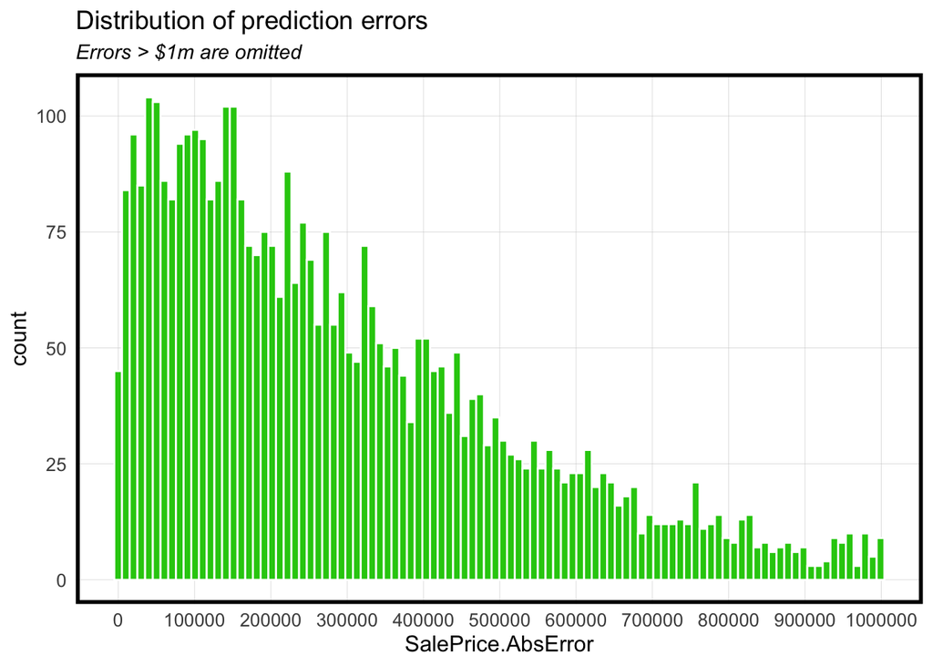

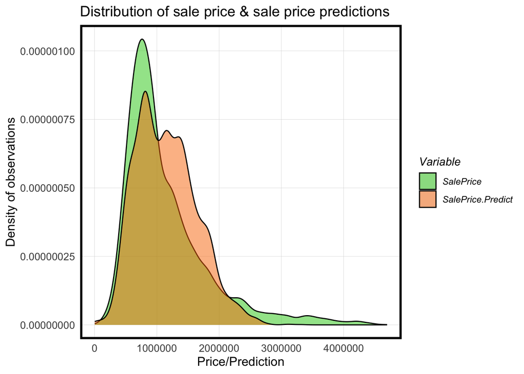

[figure not shown]

```
## Linear Regression
##
## 10744 samples
##    13 predictor
##
## No pre-processing
## Resampling: Cross-Validated (100 fold)
## Summary of sample sizes: 10637, 10636, 10638, 10636, 10637, 10636, ...
## Resampling results:
##
##   RMSE    Rsquared   MAE
##   508966  0.4664593  358200.8
##
## Tuning parameter 'intercept' was held constant at a value of TRUE
```

```
##        RMSE  Rsquared      MAE Resample
## 1  597718.5 0.5129947 400185.6  Fold001
## 2  479586.4 0.5276294 356532.2  Fold002
## 3  529729.5 0.4821907 378535.4  Fold003
## 4  606055.0 0.4085681 401637.7  Fold004
## 5  484053.3 0.4737479 338838.4  Fold005
## 6  443232.9 0.5214877 320547.5  Fold006
## 7  517003.6 0.4952176 341656.4  Fold007
## 8  475326.2 0.5024867 319383.8  Fold008
## 9  459137.5 0.4662155 337992.3  Fold009
## 10 536572.4 0.4171872 388396.8  Fold010
```

```
## [1] 34249.22
```

```
## [1] 1149641
```

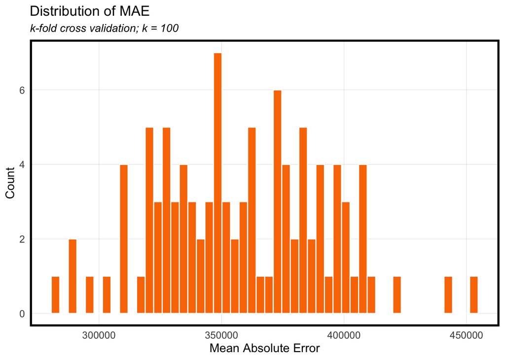

[figure not shown]

### Predicted vs. Observed

```r
ggplot(trainTable, aes(SalePrice.Predict, SalePrice)) +
  geom_point() +
  stat_smooth(data=trainTable, aes(SalePrice, SalePrice),
             method = "lm", se = FALSE, size = 1, colour="#FA7800") +
  stat_smooth(data=trainTable, aes(SalePrice, SalePrice.Predict),
              method = "lm", se = FALSE, size = 1, colour="#25CB10") +
  labs(title="Predicted sale price as a function of\nobserved price",
       subtitle="Orange line represents a perfect prediction; Green line represents prediction") +
  theme(plot.title = element_text(size = 18,colour = "black"))
```

[output not shown]

### Map - Model Residuals and Moran’s I test

```r
grid.arrange(
  ggplot() +
    geom_sf(data = baseMap, fill = "grey40") +
    geom_sf(data = trainTable2, aes(colour = q5(SalePrice)), show.legend = "point", size = 1) +
    scale_colour_manual(values = palette5,
                     labels=qBr(trainTable,"SalePrice"),
                     name="Quintile\nBreaks") +
    labs(title="Test set sale prices") +
    mapTheme(),

  ggplot() +
    geom_sf(data = baseMap, fill = "grey40") +
    geom_sf(data = trainTable2, aes(colour = q5(SalePrice.Error)), show.legend = "point", size = 1) +
    scale_colour_manual(values = palette5,
                     labels=qBr(trainTable,"SalePrice.Error"),
                     name="Quintile\nBreaks") +
    labs(title="Sale price errors on the test set") +
    mapTheme(),
  ncol = 2)

ggplot(as.data.frame(moranTest$res[c(1:999)]), aes(moranTest$res[c(1:999)])) +
  geom_histogram(binwidth = 0.01) +
  geom_vline(aes(xintercept = moranTest$statistic), colour = "#FA7800",size=1) +
  scale_x_continuous(limits = c(-1, 1)) +
  labs(title="Observed and permuted Moran's I",
       subtitle= "Observed Moran's I in red",
       x="Moran's I",
       y="Count",
       caption="Public Policy Analytics, Figure 6.8") +
  plotTheme()
```

[output not shown]

### Map - Predicted Values

```r
ggplot() +
  geom_sf(data = baseMap, fill = "grey40") +
  geom_sf(data = trainTable3, aes(colour = q5(SalePrice.Predict)), show.legend = "point", size = 1) +
  scale_colour_manual(values = palette5,
                   labels=qBr(trainTable,"SalePrice.Predict"),
                   name="Quintile\nBreaks") +
  labs(title="Entire set predicted sale prices") +
  mapTheme()
```

[output not shown]

### Generalizability

```r
acsData2 <-
  get_acs(geography = "tract", variables = c("B01001_001E","B02008_001","B06011_001"),
          year = 2017, state=06, county=075, geometry=T) %>%
  dplyr::select(variable, estimate, GEOID) %>%
  spread(variable, estimate) %>%
  rename(TotalPop = B01001_001,
         NumberWhites = B02008_001,
         MedianIncome = B06011_001) %>%
  mutate(percentWhite = NumberWhites / TotalPop,
         raceContext = ifelse(percentWhite > .5, "Majority White", "Majority Non-White"),
         incomeContext = ifelse(MedianIncome > 32322, "High Income", "Low Income"))

acsData2 <- acsData2[!(acsData2$GEOID=="06075017902"),]

grid.arrange(
  ggplot() +
    geom_sf(data = na.omit(acsData2), aes(fill = raceContext)) +
    scale_fill_manual(values = c("#25CB10", "#FA7800"),
                      name="Race Context") +
    labs(title = "Race Context") +
    mapTheme() + theme(legend.position="bottom"),

  ggplot() +
    geom_sf(data = na.omit(acsData2), aes(fill = incomeContext)) +
    scale_fill_manual(values = c("#25CB10", "#FA7800"),
                      name="Income Context") +
    labs(title = "Income Context") +
    mapTheme() + theme(legend.position="bottom"), ncol = 2)
```

[output not shown]